# Home

# Andrea Ponce

## Marketing Management Student | Cal Poly Pomona | Graduating Summer 2026

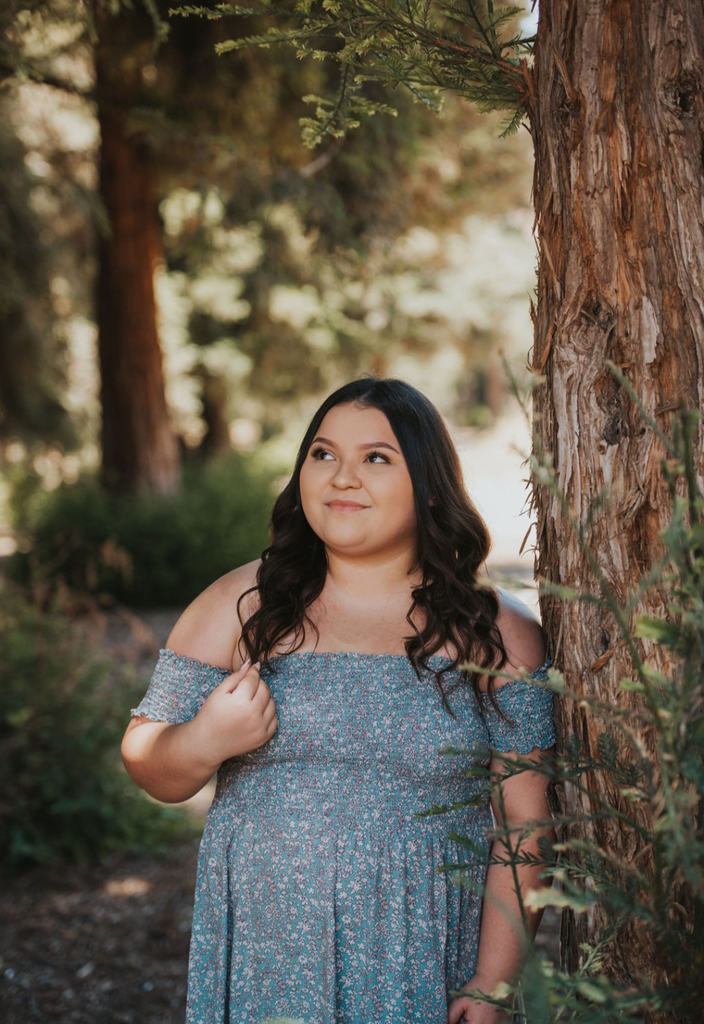

Welcome to my professional portfolio. I am a Marketing Management student with interests in digital marketing, marketing analytics, branding, and content strategy.

This website highlights selected coursework and projects using tools such as RStudio, Quarto, Tableau, Google Analytics 4, Excel, and Canva.

View My Projects View Resume

## About Me

I am passionate about using marketing strategy and data-driven insights to better understand audiences, improve content, and support stronger brand decisions. Through my coursework and hands-on projects, I have gained experience in analytics, data visualization, campaign planning, SEO, and digital content creation.

## Areas of Interest

**Marketing Analytics**  
Using data to understand customer behavior, evaluate performance, and support marketing decisions.

**Digital Marketing**  
Creating and analyzing content across digital platforms to improve reach, engagement, and visibility.

**Brand Strategy**  
Developing creative marketing ideas that connect with target audiences and strengthen brand identity.

## Featured Skills

- Google Analytics 4
- Tableau
- RStudio & Quarto
- Excel
- SEO Analysis
- Data Visualization
- Social Media Content
- Presentation Design

## Featured Projects

**Business Rebranding Project**  
Developed a rebranding strategy focused on consumer analysis, brand positioning, and visual presentation design.

**Google Analytics 4 Analysis**  
Used GA4 reports to understand website traffic, engagement, events, and digital marketing performance.

**Tableau Data Visualization Projects**  
Created visualizations and dashboards to identify trends, patterns, and marketing insights.

View All Projects

## Connect With Me

- [LinkedIn](https://www.linkedin.com/in/andrea-ponce-051042340/)
- Email: aponce3129@gmail.com